# ADM_Final

So Mang Han, Charlotte Roiger, Xiaojun Zheng

5/21/2018

```r
library(readr)
library(tidyverse)
library(stringr)
library(tm)
library(ggplot2)
library(ggthemes)
library(wordcloud)
library(Matrix)
library(FeatureHashing)
library(randomForest)
library(e1071)
library(MASS)
library(cluster)
library()
```

# Introduction

In this project, we are going to compare two different data organization methods on text classification.Specifically, we will work on three algorithms for each method including Linear Model, Linear Discriminant Analysis and Random Forest as the evidence. At the same time, we will record the time consumed for each algorithm to test the effeciency both processes.

# Data cleaning Process

We got the data from [Kaggle](https://www.kaggle.com/bharadwaj6/kindle-reviews). This data is a 5-core dataset of product reviews from Amazon Kindle Store category from May 1996 - July 2014. Contains total of 982619 entries. Each reviewer has at least 5 reviews and each product has at least 5 reviews in this dataset. We eliminated reviews that did not have a rating or did not have more than a one word review.

```r
SCXdataDir <- "/home/roiger1/ADM_Midterm/ADM Final/"
kindle <- read_csv(file.path(SCXdataDir,"kindle2.csv"), col_names = FALSE)

names(kindle) <- c("X", "review.text", "overall")
kindle <- kindle[, c("review.text", "overall")]

kindle$review.text <- sapply(strsplit(kindle$review.text, split=':', fixed=TRUE), function(x) (x[2]))

kindle.small <- kindle %>%
  filter(grepl(".0", kindle$overall)==TRUE)

kindle.small <- kindle.small %>%
  filter(nchar(kindle.small$overall) < 15)

kindle.small$overall <- sapply(strsplit(kindle.small$overall, split=':', fixed=TRUE), function(x) (x[2]))


kindle.small <- kindle.small %>%
  filter(is.na(kindle.small$overall)==FALSE,
         kindle.small$overall != " [0",
         kindle.small$overall != " [10",
         kindle.small$overall != "01 PM")

kindle.small$overall<- as.factor(as.numeric(kindle.small$overall))

kindle.small2=kindle.small[complete.cases(kindle.small), ]

dim(kindle.small2)
```

```
## [1] 63611     2
```

After cleaning, we have 63611 reviews(still plenty of data)!

However, we are going to use 10000 reviews because it takes a lot of time to run our code (still takes a long time to run using 10000 reviews)

```r
set.seed(1234)
subset<- sample(1:nrow(kindle.small2),10000)

##smaller set
kindle.df<- kindle.small2[subset,]
```

One of example of reviews looks like “I read this book in a day (it helped being snowed in) but Mason is definitely swoonworthy! It was a well written story and I would recommend to others!!”

# Motivation

Here is an example to convert a raw text to a usable format for text classification.

**Raw text**

- John likes to watch movies.
- Mary likes movies too.
- John also likes football.

##### Step 1: Finding the unique words

```r
Term<- c("jonh","likes","to","watch","movies","mary","too","also","football")
Index<- seq(1,9,1)
```

##### Step 2: Convert it to a term-document matrix

```r
example<- data.frame("jonh"=c(1,0,1),"likes"=c(1,1,1),"to"=c(1,0,0),"watch"=c(1,0,0),"movies"=c(1,1,0),"mary"=c(0,1,0),"too"=c(0,1,0),"also"=c(0,0,1),"football"=c(0,0,1))
example
```

```
##   jonh likes to watch movies mary too also football
## 1    1     1  1     1      1    0   0    0        0
## 2    0     1  0     0      1    1   1    0        0
## 3    1     1  0     0      0    0   0    1        1
```

A notable issue with dictionaries like the one shown above is that they tend to take up a large amount of storage and only grow in size as the training set grows. Feature hashing is a powerful tool to convert the raw text to a manageable numeric matrix to save space. Each unique word will be assigned a number based on a hash function, and there might be some overlapping of the values if we have many words, but not many numbers to assign. Thus, one thing that we can adjust in hashing process is the hash size, which is the maximum of the of the number that each word can be assigned to. If we use a small hash size, we would lose lots of information in the original text file. But if we use a large hash size, we are not saving any space and time. Therefore, choosing an optimal hash size is important, but that is not our focus in this project.

## Feature hashing (First data organization method)

So, we used feature hashing as our first data organization method and divided the hashed data into training data and testing data (70% training and 30% testing).

```r
hash.df <- hashed.model.matrix(~ split(review.text, delim = " ", type = "tf-idf"),
                          data = kindle.df, hash.size = 2^9, signed.hash = FALSE)

hash.df<- as.data.frame(as.matrix(hash.df))
hash.df$overall<-kindle.df$overall
train<- sample(1:nrow(hash.df),(0.7*nrow(hash.df)))
train.df<- hash.df[train,]
test.df<- hash.df[-train,]
```

## Frequency Based Word Selection (Second data organization method)

Our data without feature hashing looks like this, so we only kept the words which have the frequency higher than 20, and this is our second data organization method.

```r
sourceData <- VectorSource(kindle.df$review.text)
corpus <- Corpus(sourceData)

corpus <- tm_map(corpus, content_transformer(tolower)) # convert to lowercase
corpus <- tm_map(corpus, removeNumbers) # remove digits
corpus <- tm_map(corpus, removePunctuation) # remove punctuation
corpus <- tm_map(corpus, stripWhitespace) # strip extra whitespace
corpus <- tm_map(corpus, removeWords, stopwords('english')) # remove stopwords, such as "a", "the", "at", etc.

tdm <- DocumentTermMatrix(corpus)

# Subset by words with a frequency
keepterm <- findFreqTerms(tdm, lowfreq = 20, highfreq = Inf)
tdm2 <- tdm[,keepterm]

#Create a data frame with corpus data.
tdm2 <- as.data.frame(as.matrix(tdm2))

# Add rating to tdm2 data frame
tdm2$overall.rating <- kindle.df$overall

# Changing names so Random Forest will be my friend
colnames(tdm2)[colnames(tdm2)=="else"] <- "else.o"
colnames(tdm2)[colnames(tdm2)=="next"] <- "next.o"
colnames(tdm2)[colnames(tdm2)=="break"] <- "break.o"

# Subset into Train and Test
set.seed(12345)
split <- sample(nrow(tdm2), floor(0.7*nrow(tdm2)))
tdm2Train <-tdm2[split,]
tdm2Test <- tdm2[-split,]
```

# Research Question

We will compare the two data organization methods: (1). Feature Hashing, and (2). Frequency Based Word Selection. Our research question is whether Feature Hashing is more efficient or accurate than the Frequency Based Word Selection method. We will measure our results with error rates and the amount of time consumed to construct models.

# Exploratory Data Analysis

We used `tm` library to text analysis. We found out most frequent words in reviews and made a wordcloud of reviews and hierarchical clustering plot.

```r
colS <- colSums(as.matrix(tdm))
doc_features <- data.table::data.table(name = attributes(colS)$names, count = colS)

#most frequent and least frequent words
doc_features[order(-count)][1:10] #top 10 most frequent words
```

```
##       name count
##  1:   book  8171
##  2:   read  4823
##  3:  story  4168
##  4:   love  2626
##  5:   good  2489
##  6:  great  2416
##  7:    one  2216
##  8: series  2168
##  9: really  1837
## 10:   will  1830
```

```r
doc_features[order(count)][1:10] #least 10 frequent words
```

```
##                       name count
##  1:            swoonworthy     1
##  2:                  lexis     1
##  3:                  widen     1
##  4:                    opp     1
##  5:         lawddddyyyythe     1
##  6:      fanfreakingtastic     1
##  7:           unbeleivable     1
##  8: rebeccaevanshotmailcom     1
##  9:                thoghts     1
## 10:              miserable     1
```

We created a histogram for frequent words(more than 1500 frequencies).

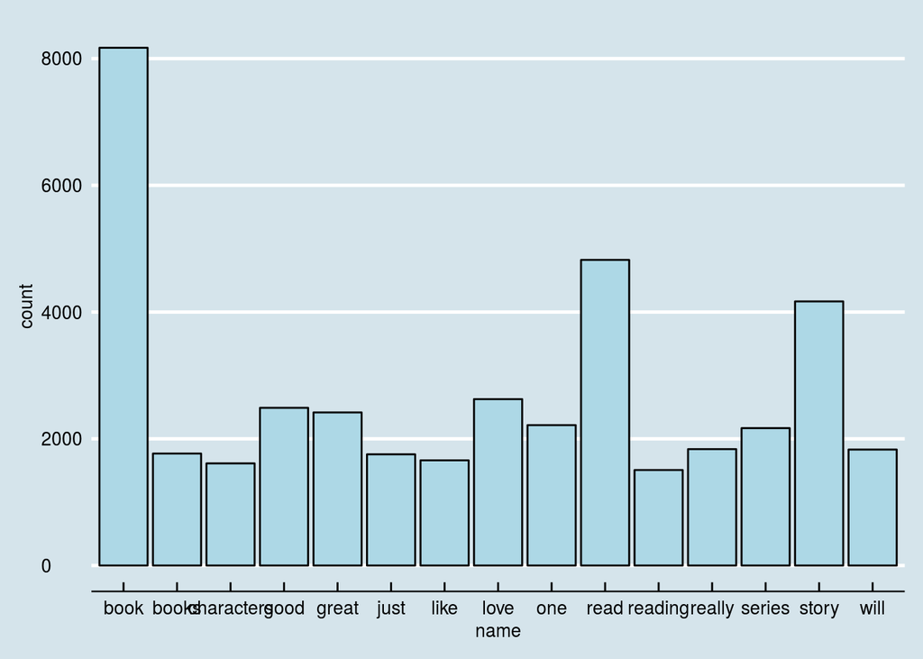

```r
ggplot(doc_features[count>1500],aes(name, count)) +geom_bar(stat = "identity",fill='lightblue',color='black')+theme(axis.text.x = element_text(angle = 45, hjust = 1))+theme_economist()+scale_color_economist()
```

Here is a wordcloud plot just for fun!

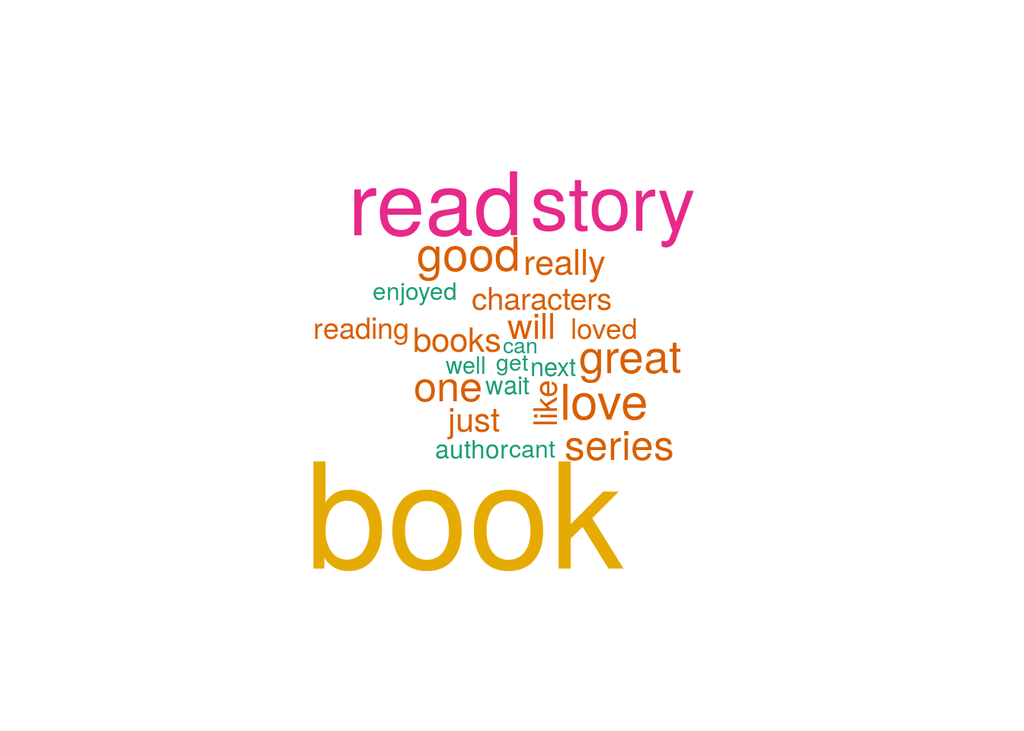

```r
wordcloud(names(colS), colS, min.freq = 1000, scale = c(6,.1), colors = brewer.pal(6, 'Dark2'))
```

And also created a histogram for rating distribution. Lots of 5, which implies that the majority people liked their book(s).

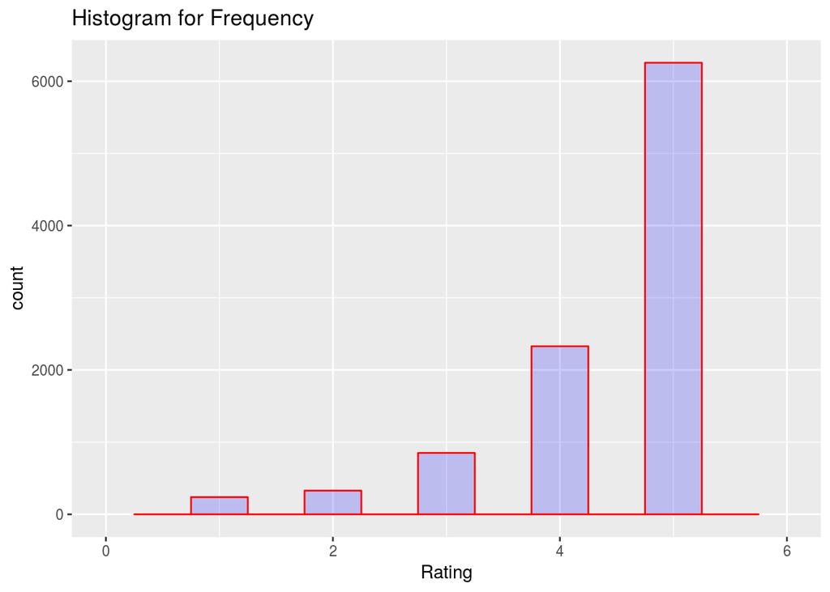

```r
hash.df$overall=as.numeric(hash.df$overall)

qplot(hash.df$overall,geom="histogram",binwidth = 0.5,  main = "Histogram for Frequency", xlab = "Rating",fill=I("blue"), col=I("red"), alpha=I(.2),xlim=c(0,6))
```

Here is a hierarchical clustering plot for our data.

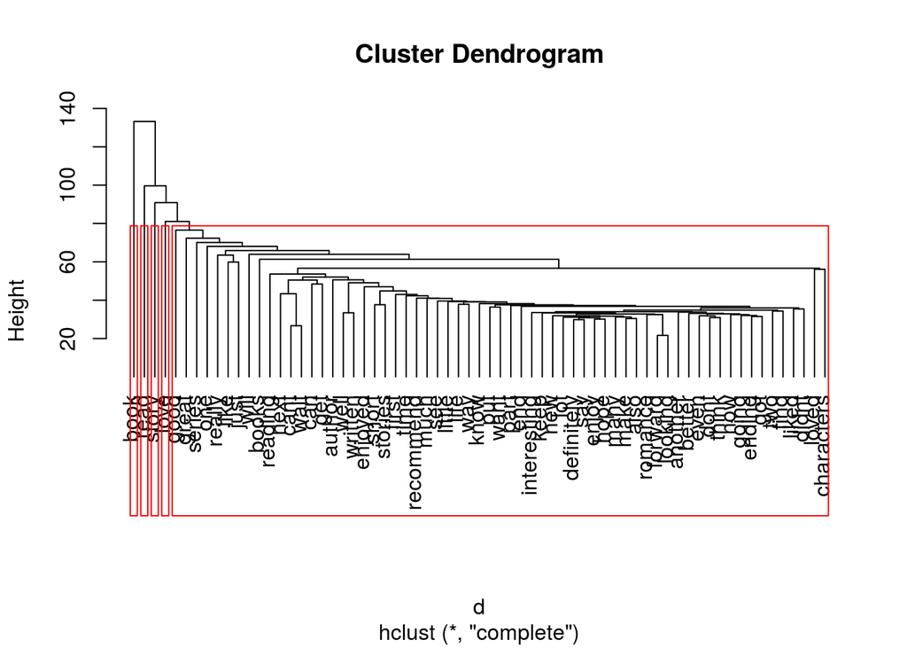

```r
dtms <- removeSparseTerms(tdm, 0.96) # This makes a matrix that is 96% empty space, maximum.
freq <- colSums(as.matrix(dtms))
d <- dist(t(dtms), method="euclidian")
fit <- hclust(d=d, method="complete")
plot.new()
plot(fit, hang=-1)
groups <- cutree(fit, k=5)   # "k=" defines the number of clusters you are using
rect.hclust(fit, k=5, border="red")
```

# Modelling

## Linear Model

Now we will construct linear models for both our feature-hashed and non-feature hashed data sets. We will compare the error rates of each model.

#### Feature-Hashed

```r
#Time the creationg of the Linear Model
st <- Sys.time()
mod.lm <- lm(overall~.,data=train.df)
end <- Sys.time();

hashed.lm.time<- end - st

# Predict on testing data
pred<- predict(mod.lm,newdata=test.df)

# Round our predictions to a whole number
test.df$pred.lm <- round(pred)
test.df$pred.lm<- ifelse(round(pred)==6,5,round(pred))

# Confusion Matrix
with(test.df,table(pred.lm,overall))
```

```
##        overall
## pred.lm    1    2    3    4    5
##       1    0    1    0    2    1
##       2    3    0    0    1    1
##       3    8   19   33   22   23
##       4   70   84  160  411  850
##       5    6    7   33  262 1001
##       7    0    0    0    0    2
```

```r
# Error Rate
hashed.error.lm <- sum(test.df$overall!= test.df$pred.lm,na.rm=T)/nrow(test.df)


# Cross-Validate Error Rate Function
errCV <- function(data.df,kfolds=10){
  folds <- sample(1:kfolds,sampleSize,rep=T)
  err <- rep(0,kfolds)
  for(k in 1:kfolds){
    train.df <- data.df[folds !=k,]
    test.df <- data.df[folds==k,]
    mod.lm <- lm(overall~.,data=train.df)
    vals <- predict(mod.lm,newdata=test.df)
    test.df$pred.lm <- round(vals)
    err[k]<- sum(test.df$overall!= test.df$pred.lm,na.rm=T)/nrow(test.df)
  }
  mean(err)
}
```

```r
#Set sample size
sampleSize <- nrow(hash.df)

hash.df$overall <- as.numeric(hash.df$overall)

# Cv error
errCV(hash.df)
```

```r
CV.hashed.error.lm <- 0.518
```

For the Feature-hashed review data frame the error rate is 0.518333333333333 and the cross-validated error rate is 0.518 these are relatively similar.

### Non-Feature-Hashed

```r
# Time how long it takes to make linear model
st <- Sys.time()
lin.mod <- lm(overall.rating~., data = tdm2Train)
end <- Sys.time()

nonhashed.lm.time <- end-st

#Make Prediction and round
pred <- predict(lin.mod, newdata = tdm2Test)
tdm2Test$pred.lm <- round(pred)
tdm2Test$pred.lm<- ifelse(round(pred)==6,5,round(pred))

#Confusion Matrix
with(tdm2Test,table(pred.lm,overall.rating))
```

```
##        overall.rating
## pred.lm    1    2    3    4    5
##      -2    0    1    0    0    0
##      -1    0    0    0    1    0
##      0     0    0    1    0    0
##      1     1    0    1    0    1
##      2    10    5   13    5    1
##      3    21   31   56   44   47
##      4    43   49  155  372  773
##      5     3    7   27  240 1077
##      7     0    0    0    2    9
##      8     0    0    0    0    3
##      11    0    0    0    0    1
```

```r
nonhashed.error.lm <- sum(tdm2Test$overall.rating!= tdm2Test$pred.lm,na.rm=T)/nrow(tdm2Test)


# Cross-Validate Error Rate Function
errCV <- function(data.df,kfolds=10){
  folds <- sample(1:kfolds,sampleSize,rep=T)
  err <- rep(0,kfolds)
  for(k in 1:kfolds){
    train.df <- data.df[folds !=k,]
    test.df <- data.df[folds==k,]
    mod.lm <- lm(overall.rating~.,data=train.df)
    vals <- predict(mod.lm,newdata=test.df)
    test.df$pred.lm <- round(vals)
    err[k]<- sum(test.df$overall.rating!= test.df$pred.lm,na.rm=T)/nrow(test.df)
  }
  mean(err)
}
```

```r
#Set Sample Size
sampleSize <- nrow(tdm2)

#Convert to Numeric
tdm2$overall.rating <- as.numeric(tdm2$overall.rating)

#CV error rate.
errCV(tdm2)
```

```r
CV.nonhashed.error.lm <- 0.509
```

Now for the non-Feature-Hashed data set we see that the error rate for the model and the cross validation are 0.496333333333333 and 0.509 respectively, which are similar.

## Linear Discriminant Analysis

### Feature-Hashed

```r
# Time the creationg of the Linear Model
st <- Sys.time()
mod.lda <- lda(overall~.,data=train.df)
end<- Sys.time()

hashed.lda.time<- end - st

# Predict over testing data
pred<- predict(mod.lda,newdata=test.df)
test.df$pred.lda <- pred$class

# Confusion Matrix
with(test.df,table(pred.lda, overall))
```

```
##         overall
## pred.lda    1    2    3    4    5
##        1    7    9    3    7   19
##        2   11   20   13   12   21
##        3    2   18   47   48   40
##        4    9    6   52  124  170
##        5   58   58  111  507 1628
```

```r
# Error Rate
hashed.error.lda <- sum(test.df$overall!= test.df$pred.lda,na.rm=T)/nrow(test.df)
hashed.error.lda
```

```
## [1] 0.3913333
```

```r
# Cross Validation

sampleSize <- nrow(kindle.df)

errCV <- function(data.df,kfolds=10){
  data.df=hash.df
  kfolds=10
  folds <- sample(1:kfolds,sampleSize,rep=T)
  err <- rep(0,kfolds)
  for(k in 1:kfolds){
    train.df <- data.df[folds !=k,]
    test.df <- data.df[folds==k,]
    mod.lda <- lda(overall~.,data=train.df)
    vals <- predict(mod.lda,newdata=test.df)
    test.df$pred.lda <- vals$class
    err[k]<- sum(test.df$overall!= test.df$pred.lda,na.rm=T)/nrow(test.df)
  }
  mean(err)
}
```

```r
errCV(hash.df,10)
```

```r
CV.hashed.error.lda <- 0.382
```

For the Feature-hashed data frame the error rate is 0.391333333333333 and the cross-validated error rate is 0.382 these are relatively similar.

### Non-Feature-Hashed Data

```r
# Time the creationg of the Linear Model
st <- Sys.time()
mod.lda <- lda(overall.rating~.,data=tdm2Train)
end <- Sys.time()

nonhashed.lda.time <- end - st

# Make Predictions on Testing Data
pred<- predict(mod.lda,newdata=tdm2Test)

tdm2Test$pred.lda <- pred$class

# Confusion Matrix
with(tdm2Test,table(pred.lda,overall.rating))
```

```
##         overall.rating
## pred.lda    1    2    3    4    5
##        1   16   11   11   10   24
##        2   10   12   10   21   37
##        3   15   21   65   46   70
##        4    9   12   73  179  241
##        5   28   37   94  408 1540
```

```r
nonhash.error.lda<- sum(tdm2Test$overall.rating!= tdm2Test$pred.lda,na.rm=T)/nrow(tdm2Test)

sampleSize <- nrow(tdm2)

errCV <- function(data.df,kfolds=5){
  folds <- sample(1:kfolds,sampleSize,rep=T)
  err <- rep(0,kfolds)
  for(k in 1:kfolds){
    train.df <- data.df[folds !=k,]
    test.df <- data.df[folds==k,]
    mod.lda <- lda(overall.rating~.,data=train.df)
    vals <- predict(mod.lda,newdata=test.df)
    test.df$pred.lda <- vals$class
    err[k]<- sum(test.df$overall.rating!= test.df$pred.lda,na.rm=T)/nrow(test.df)
  }
  mean(err)
}
```

```r
errCV(tdm2)
```

```r
CV.nonhashed.error.lda <- 0.395
```

Now for the non-Feature-Hashed data set we see that the error rate for LDA is 0.396 and the cross validation are 0.395 respectively, which are similar.

## Random forest

### Feature-Hashed

```r
# Duplicate data frames for RF
train.df1=train.df
test.df1=test.df

#change column names

colnames(train.df1)=NULL
colnames(train.df1)[513]="overall"

a1=c(1:512)
col_name=paste("Column",a1,sep='')
colnames(train.df1)[1:512]=col_name
colnames(train.df1)[513]="overall"

# Calculate the time to create the random forest with
st <- Sys.time()
overall.forest <- randomForest(overall~.,data=train.df1,ntree=100)
end <- Sys.time();

hashed.rf.time<- end - st

# Change column names
colnames(test.df1)=NULL
colnames(test.df1)[513]="overall"

a1=c(1:512)
col_name=paste("Column",a1,sep='')
colnames(test.df1)[1:512]=col_name
colnames(test.df1)[513]="overall"

# Predict error rate over test data
preds.forest <- predict(overall.forest ,newdata=test.df1)

# Error Rate
hashed.error.rf<- with(test.df,mean(overall!=preds.forest))
```

Finding the optimal tree number

```r
error_all<- c()

for (i in c(100,100)){
  preds.forest <- predict(overall.forest ,newdata=test.df1)
  err<- with(test.df1,mean(overall!=preds.forest))
  error_all<- c(error_all,err)
  overall.forest=grow(overall.forest,i)
}
error_all
```

[output not shown]

```r
###Cross-validation for random forest

sampleSize <- nrow(kindle.df)

errCV <- function(data.df,kfolds=3){
  data.df=hash.df
  kfolds=2
  folds <- sample(1:kfolds,sampleSize,rep=T)
  err <- rep(0,kfolds)
  for(k in 1:kfolds){
    train.df2 <- data.df[folds !=k,]
    test.df2 <- data.df[folds==k,]
    colnames(train.df2)=NULL
    colnames(train.df2)[513]="overall"
    colnames(train.df2)[1:512]=col_name
    colnames(train.df2)[513]="overall"
    colnames(test.df2)[1:512]=col_name
    colnames(test.df2)[513]="overall"
    mod.randomforest <- randomForest(overall~.,data=train.df2,ntree=100)
   val <- predict(mod.randomforest,newdata=test.df2)
    test.df2$pred.random <- val
    err[k]<- with(test.df2,mean(overall!=pred.random))
  }
  mean(err)
}
```

```r
cv_err_randomforest=errCV(hash.df,3)
```

```r
CV.error.rf <- 0.375
```

For the Feature-hashed review data frame the error rate is 0.371 and the cross-validated error rate is 0.375 these are relatively similar.

### Non-Feature-Hashed Data

```r
st <- Sys.time()
overall.forest <- randomForest(overall.rating~., data=tdm2Train, ntree=100)
end <- Sys.time();

nonhashed.rf.time <- end-st

preds.forest <- predict(overall.forest, newdata=tdm2Test)
nonhashed.error.rf <- with(tdm2Test,mean(overall.rating!=preds.forest))
```

For the Non-hashed review data frame the error rate is 0.356. We could not get the cross validated non-Feature-Hashed error because the runtime of the crossvalidation function was much too long. Therefore we cannot compare the two cross validated error rates. But for the model error rates we have the Feature-Hashed error rate as 0.371 while the non-Feature-Hashed error rate was 0.356 which are both pretty similar.

## Subset Selection

```r
errCV <- function(data.df,kfolds=10){
  folds <- sample(1:kfolds,sampleSize,rep=T)
  err <- rep(0,kfolds)
  for(k in 1:kfolds){
    train.df <- data.df[folds !=k,]
    test.df <- data.df[folds==k,]
    mod.lda <- lda(overall.rating~.,data=train.df)
    vals <- predict(mod.lda,newdata=test.df)
    test.df$pred.lda <- vals$class
    err[k]<- sum(test.df$overall!= test.df$pred.lda,na.rm=T)/nrow(test.df)
  }
  mean(err)
}

numPreds <- length(names(tdm2))-1
allPreds <- 1:(numPreds)
currPreds <- c()
availPreds <- setdiff(allPreds,currPreds)
minerr <- c()
maxPreds <- numPreds
preds<- c()
```

```r
while(length(currPreds) < maxPreds){
    allerror <- c()
    for(id in availPreds){
        data.df <- tdm2[,c(currPreds,id,numPreds+1)]
        err <- errCV(data.df)
        allerror <- c(allerror,err)
    }
    ##Find the min
    id <- which.min(allerror)
    pred<- names(tdm2)[availPreds[id]]
    preds<- c(preds,pred)
    ##get the best predictors and MSW
    bestPred <- availPreds[id]
    besterr <- min(allerror)
    ##Add these into the collection
    currPreds <- c(currPreds,bestPred)
    minerr <- c(minerr,besterr)
    availPreds <- setdiff(allPreds,currPreds)
    ## Print stuff out for debugging and attention-grabbing
    print(c(bestPred,besterr))
    print(currPreds)
}
```

```r
words<- c("pace","god","overcome","fantastic","ebook","turned","means","hold","cause","starting","arc")
err<- c(0.362,0.360,0.359,0.358,0.357,0.357,0.356,0.356,0.355,0.355,0.355)
result.df <- data.frame(words=words, err=err)
result.df
```

```
##        words   err
## 1       pace 0.362
## 2        god 0.360
## 3   overcome 0.359
## 4  fantastic 0.358
## 5      ebook 0.357
## 6     turned 0.357
## 7      means 0.356
## 8       hold 0.356
## 9      cause 0.355
## 10  starting 0.355
## 11       arc 0.355
```

```r
### We typied in the most important words with error rate above since we did not save the results to our machines.
```

# Conclusion

```r
overall_table=data.frame(error_rate=c(hashed.error.lm, nonhashed.error.lm, hashed.error.lda, nonhash.error.lda, hashed.error.rf, nonhashed.error.rf),run_time=c(hashed.lm.time, nonhashed.lm.time, hashed.lda.time, nonhashed.lda.time, hashed.rf.time, nonhashed.rf.time))

rownames(overall_table)=c("Hashed.lm","Non.Hashed.lm","Hashed.LDA","Non.Hashed.LDA","Hashed.rf","Non.Hashed.rf")

overall_table
```

```
##                error_rate         run_time
## Hashed.lm       0.5183333    4.153463 secs
## Non.Hashed.lm   0.4963333   25.269704 secs
## Hashed.LDA      0.3913333   24.704427 secs
## Non.Hashed.LDA  0.3960000  169.418315 secs
## Hashed.rf       0.3710000  226.800447 secs
## Non.Hashed.rf   0.3560000 1184.177309 secs
```

From the table it becomes clear that the error rates are relatively similar for the Feature-Hashed and Non-Featur-Hashed data for all of the algorithms we tested in this project. We start to see differences between the two processes in terms of time differences. As the algorithms become more computationally intensive the time involved for both processes increases, however the time increases at a much greater amount for the Non-Feature-Hashed data. Therefore we can conclude that the Feature-Hashing method is a more time efficient data organization than the Frequency Based Word Selection method.